# Statistical Inference Course Project - simulation exercise

Zanin Pavel

February 27, 2016

[Link to project on GitHUB](https://github.com/Filareth2015/Statistical-Inference-Course-Project.git)

# Overview

In this project we are going to investigate the exponential distribution in R and compare it with the Central Limit Theorem.

The exponential distribution can be simulated in R with rexp(n, lambda) where lambda is the rate parameter. The mean of exponential distribution is 1/lambda and the standard deviation is also 1/lambda.  
We will set lambda = 0.2 for all of the simulations. Also we will investigate the distribution of averages of 40 exponentials. We will do a thousand simulations.

# 1. Simulations

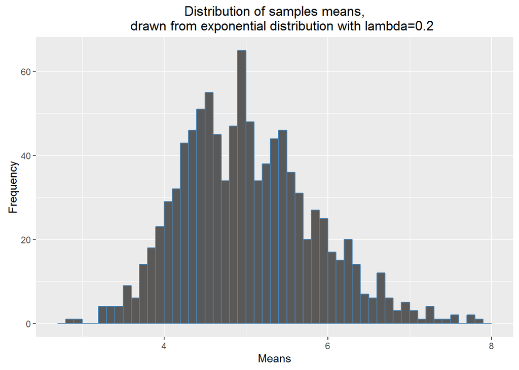

```r
# loading neccesary libraries
library(ggplot2)

# set constants
lambda <- 0.2 # rate parameter for exponential distribution
n <- 40 # number of exponetials
numberOfSimulations <- 1000 # number of simulations

# set the seed to create reproducability
set.seed(123456)

# creating matrix with observations
exponentialDistributions <- matrix(data=rexp(n * numberOfSimulations,
                                             lambda),
                                   nrow=numberOfSimulations)

# creating data frame with means of rows in the matrix
exponentialDistributionMeans <- data.frame(means=apply(exponentialDistributions, 1, mean))

# plotting the means
ggplot(data = exponentialDistributionMeans, aes(x = means)) +
              geom_histogram(binwidth=0.1, color = "steelblue") +
              labs(title = "Distribution of samples means,
    drawn from exponential distribution with lambda=0.2") +
              labs(x = "Means") +
              labs(y = "Frequency")
```

# 2. Sample Mean versus Theoretical Mean

The theoretical mean $\mu$ of a exponential distribution of rate $\lambda$ is

$\mu= \frac{1}{\lambda}$ , then $\mu$ for $\lambda$=.2 equal:

```
## [1] 5
```

Lets define sample mean and compare it with theoretical:

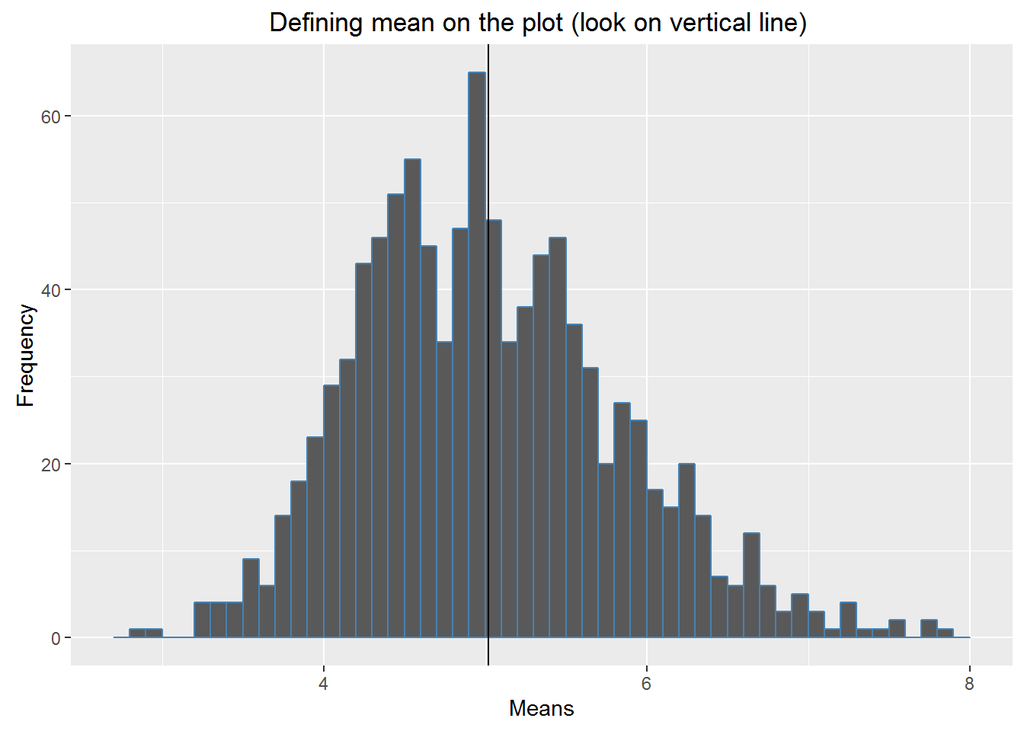

```r
# calculating sample mean
SampleMean <- mean(exponentialDistributionMeans$means)
SampleMean
## [1] 5.022915
```

**Infer:** So, as you can see the theoretical mean (5) and sample mean (5.0229151) are very close.

# 3. Sample Variance versus Theoretical Variance

The theoretical standard deviation $\sigma$ of a exponential distribution of rate $\lambda$ is: $\sigma = \frac{1/\lambda}{\sqrt{n}}$ , then $\sigma$ for $\lambda$=.2 and $n$=40 equal:

```
## [1] 0.7905694
```

The theoretical variance $Var = \sigma^2$. Then its equal:

```
## [1] 0.625
```

Lets define the sample variance ($Var_x$) and the sample standard deviation $\sigma_x$.

```r
sd_x <- sd(exponentialDistributionMeans$means)
sd_x
```

```
## [1] 0.8097816
```

```r
Var_x <- var(exponentialDistributionMeans$means)
Var_x
```

```
## [1] 0.6557463
```

**Infer:** As you can see standard deviation and variance in theory (0.7905694 and 0.625) and in the sample (0.8097816 and 0.6557463) are pretty close.

# 4. Distribution

Due to the Central Limit Theorem, the averages of samples should follow a normal distribution. Lets show it.

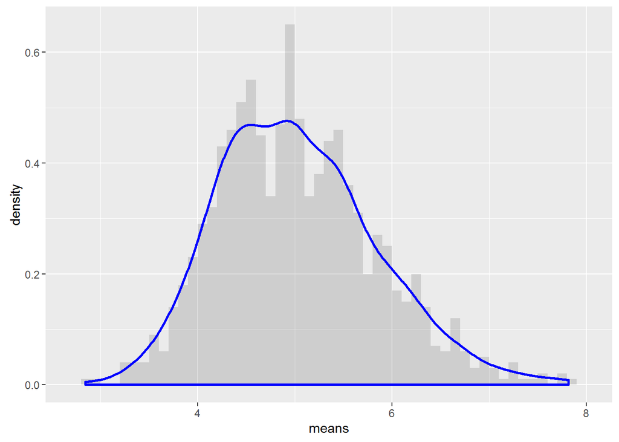